# Projet 4 : Régression en grande dimension et parcimonie

Ismail OKIEH OMAR & Nango FOFANA

# Exercice 1. Régularisation

### Question 1. Supposons que l’on observe le modèle linéaire $Y = X \theta + \xi$, avec $\xi$ un vecteur gaussien standard de dimension $n = 1000$, $\theta$ un vecteur de dimension $p = 5000$ tel que $\theta_1 = ... = \theta_15 = 1$ et les autres coordonnées sont nulles (paramètre de sparsité $s = 15$). On suppose que les colonnes X_{·,i} de X sont i.i.d. gaussiennes standard (pas corrélés).

```r
library(glmnet)
```

```r
library(MASS)
library(corrplot)
n = 1000
p = 5000
theta = matrix(c(rep(1,15),rep(0,5000-15)),ncol = 1)
epsilon = matrix(rnorm(1000),ncol = 1)
X = matrix(rnorm(5000*1000), ncol = 5000, nrow = 1000)
Y = X%*%theta + epsilon

lasso = glmnet(X, Y, family = "gaussian", alpha = 1)
cvlasso = cv.glmnet(X, Y, type.measure="mse", alpha=1, family="gaussian")
```

Pour l’estimateur Ridge aussi on a :

```r
ridge = glmnet(X, Y, family = "gaussian", alpha = 0)
cvridge = cv.glmnet(X, Y, type.measure="mse", alpha=0, family="gaussian")
```

```r
Elastic_net = glmnet(X, Y, family = "gaussian", alpha = 0.5)
cvelastic_net = cv.glmnet(X, Y, type.measure="mse", alpha=0.5, family="gaussian")
```

#### Question 1.b. Visualisation

##### Lasso

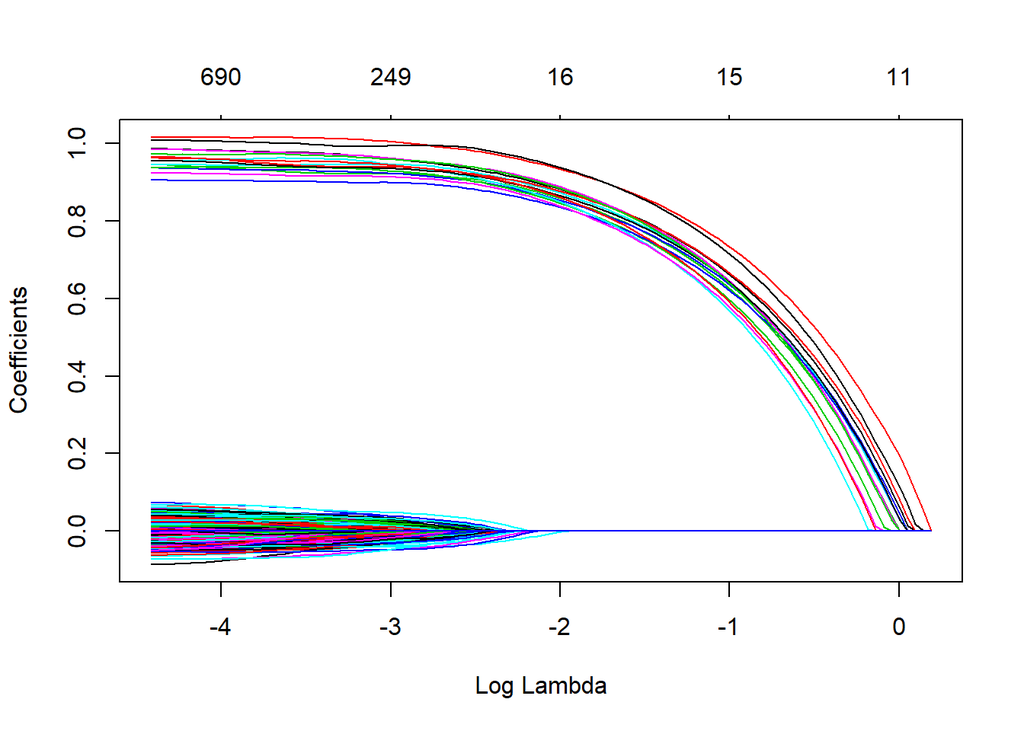

```r
plot(lasso, xvar="lambda")
```

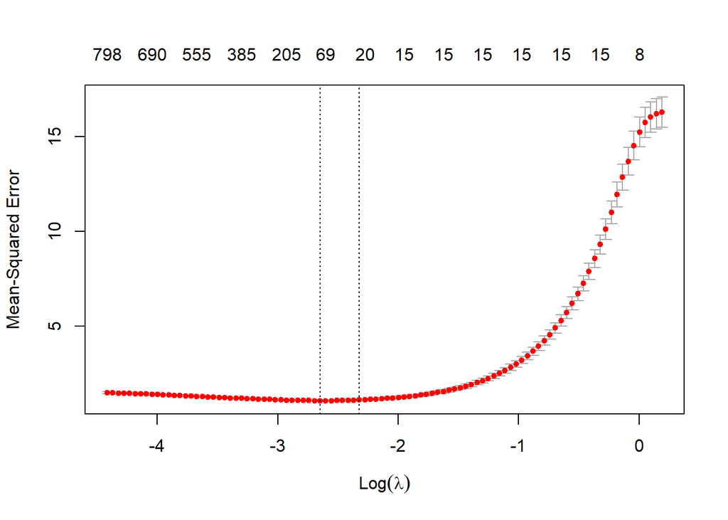

```r
plot(cvlasso)
```

##### Ridge

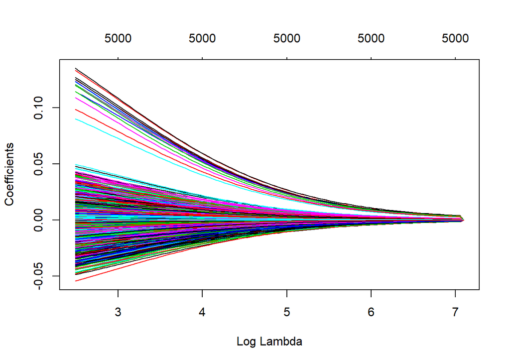

```r
plot(ridge, xvar="lambda")
```

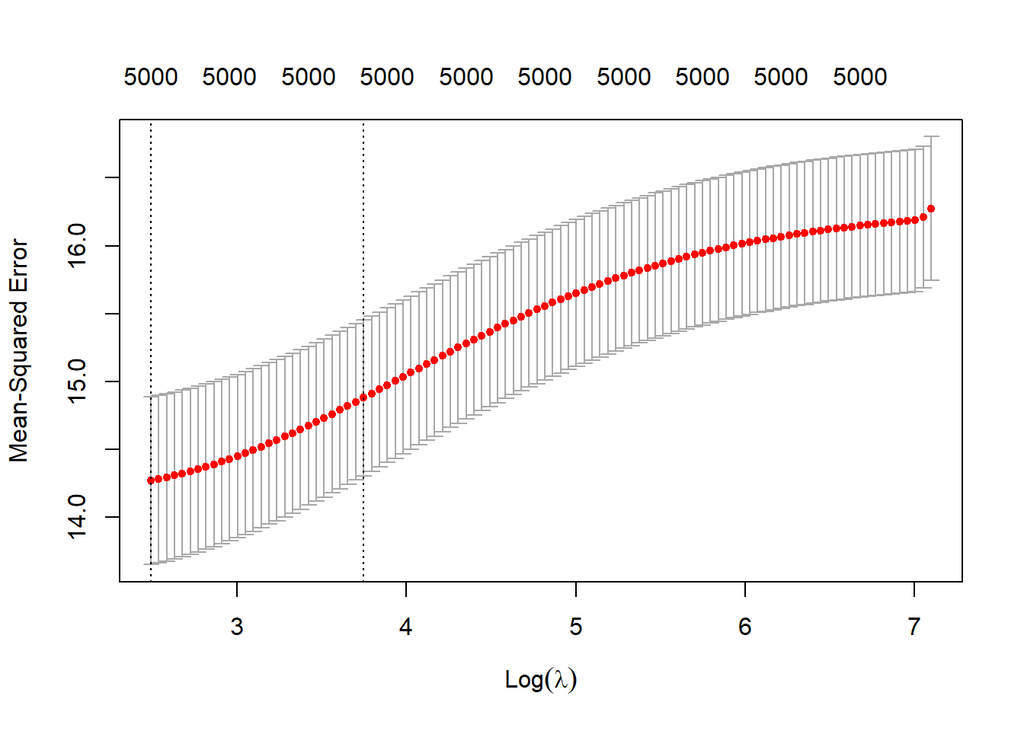

```r
plot(cvridge)
```

##### Eslatic net

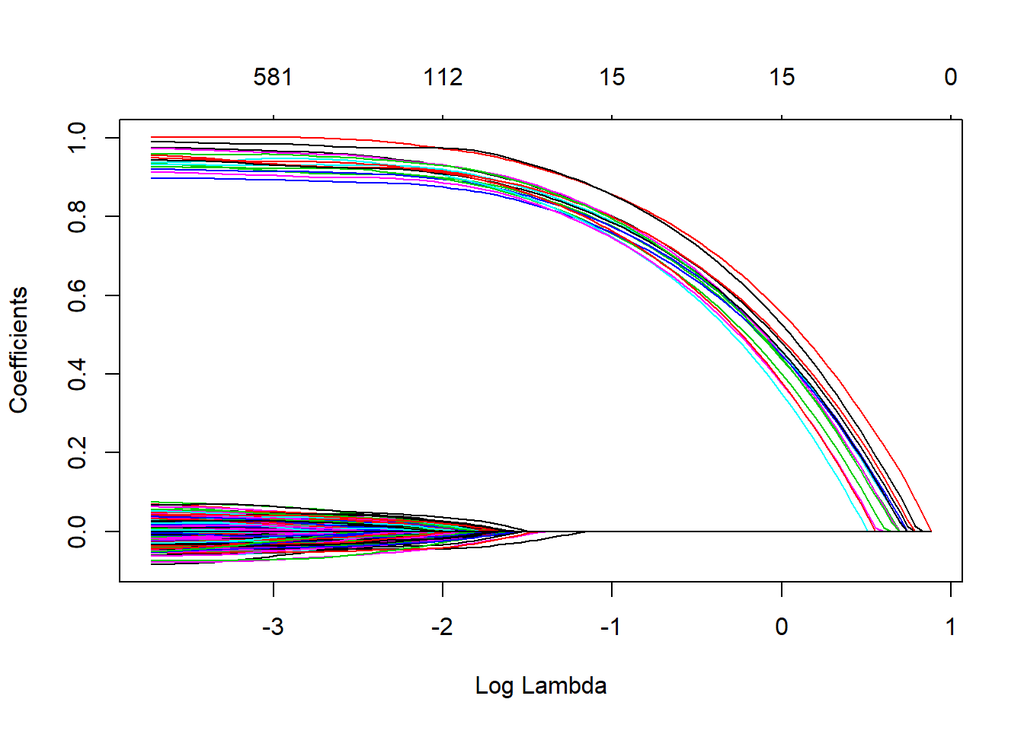

```r
plot(Elastic_net, xvar="lambda")
```

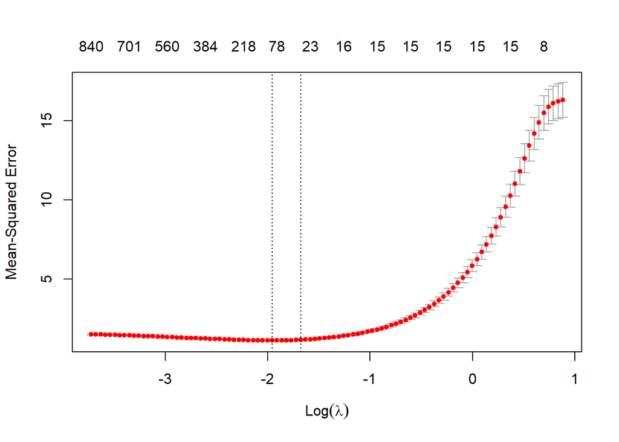

```r
plot(cvelastic_net)
```

#### Question 1.C. Sélection de l’estimateur

```r
cvlasso$lambda.min
```

```
## [1] 0.07076829
```

```r
cvridge$lambda.min
```

```
## [1] 12.08264
```

```r
cvelastic_net$lambda.min
```

```
## [1] 0.1415366
```

L’estimateur lasso fournit la meilleure prédiction, car c’est le modèle qui retourne le plus petit minimum.

### Question 2. Mêmes questions si on remplace $\theta$ par $\theta_1 = ... = \theta_1500 = 1$ et les autres coordonées sont nulles.

```r
n = 1000
p = 5000
theta = matrix(c(rep(1,1500),rep(0,5000-1500)),ncol = 1)
epsilon = matrix(rnorm(1000),ncol = 1)
X = matrix(rnorm(5000*1000), ncol = 5000, nrow = 1000)
Y = X%*%theta + epsilon

lasso2 = glmnet(X, Y, family = "gaussian", alpha = 1)
cvlasso2 = cv.glmnet(X, Y, type.measure="mse", alpha=1, family="gaussian")
```

Pour l’estimateur Ridge, on a :

```r
ridge2 = glmnet(X, Y, family = "gaussian", alpha = 0)
cvridge2 = cv.glmnet(X, Y, type.measure="mse", alpha=0, family="gaussian")
```

```r
Elastic_net2 = glmnet(X, Y, family = "gaussian", alpha = 0.5)
cvelastic_net2 = cv.glmnet(X, Y, type.measure="mse", alpha=0.5, family="gaussian")
```

## Visualisation

#### Lasso

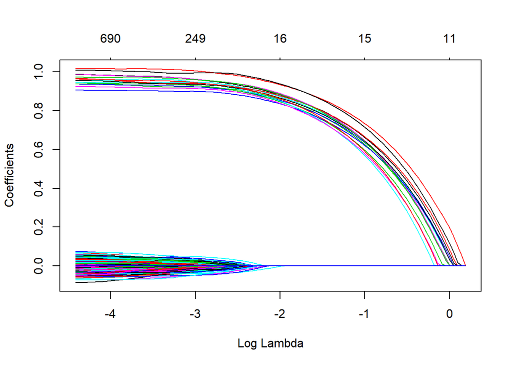

```r
plot(lasso, xvar="lambda")
```

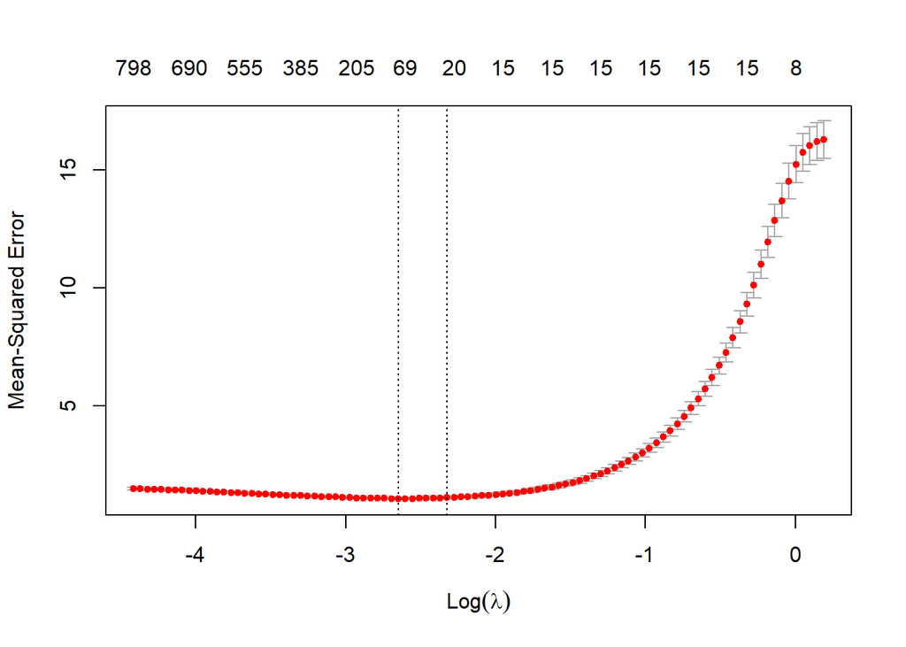

```r
plot(cvlasso)
```

#### Ridge

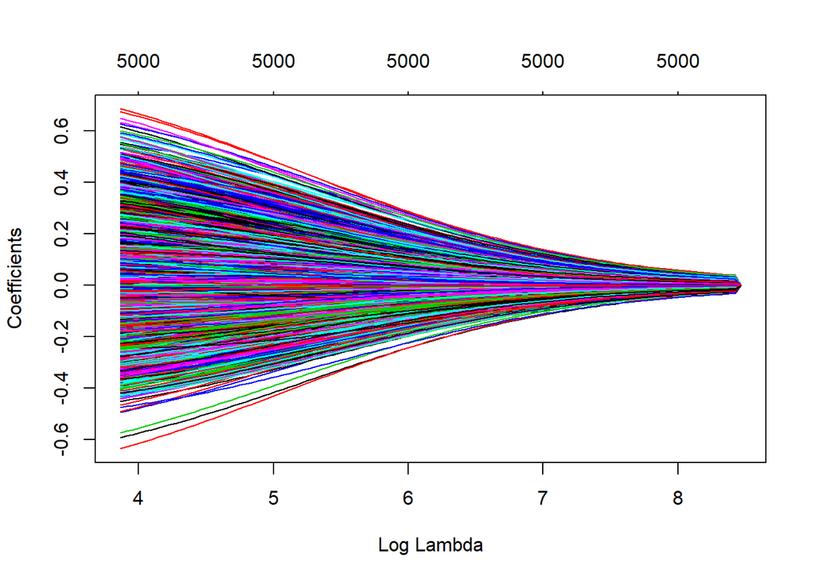

```r
plot(ridge2, xvar="lambda")
```

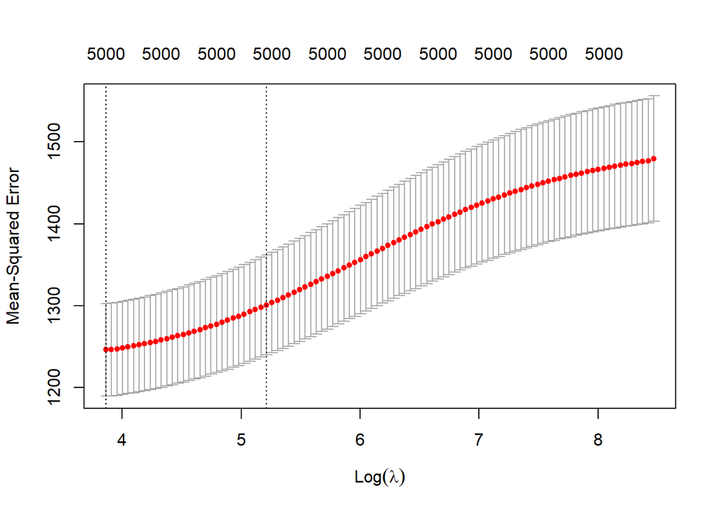

```r
plot(cvridge2)
```

#### Eslatic net

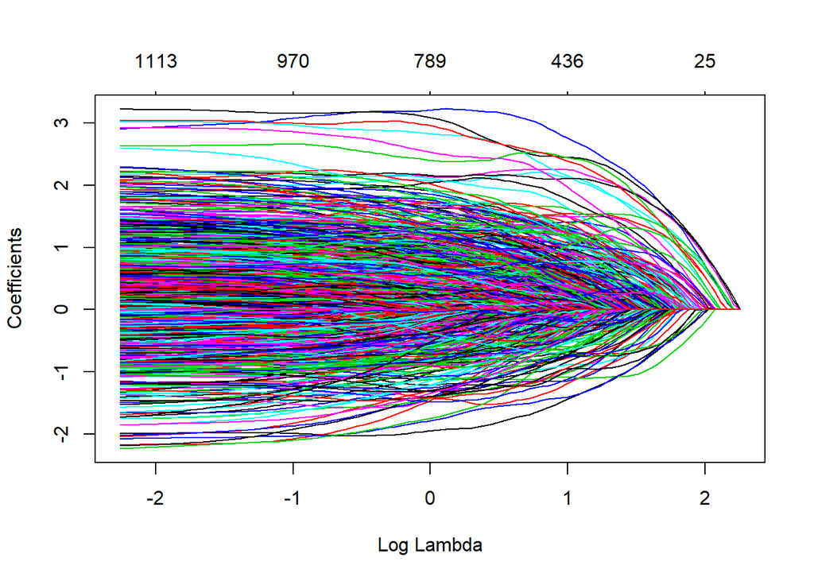

```r
plot(Elastic_net2, xvar="lambda")
```

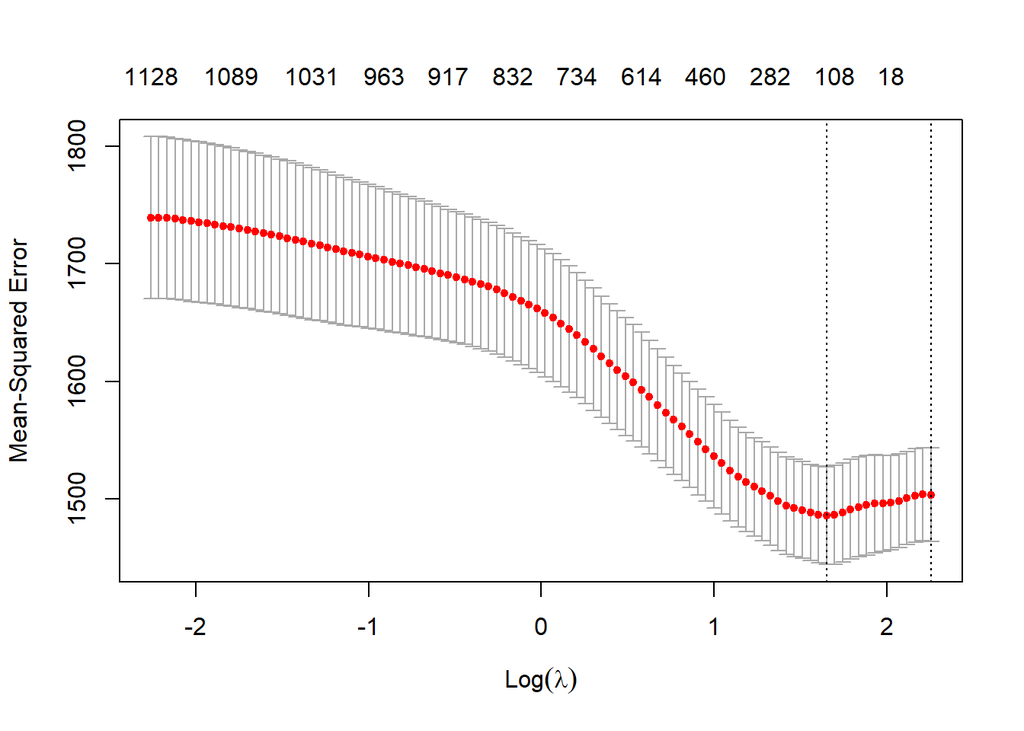

```r
plot(cvelastic_net2)
```

```r
cvlasso2$lambda.min
```

```
## [1] 2.854173
```

```r
cvridge2$lambda.min
```

```
## [1] 47.61048
```

```r
cvelastic_net2$lambda.min
```

```
## [1] 5.201233
```

.

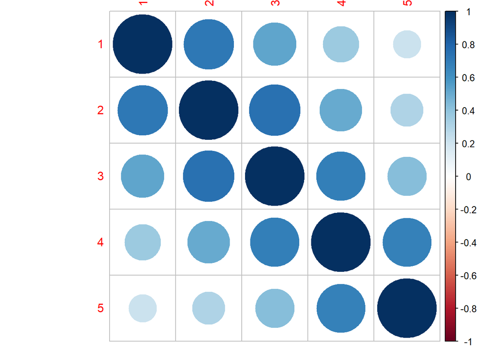

```r
n = 100
p = 50
sigma = matrix(NA, 50, 50)
for(i in 1:50){
  for(j in 1:50){
    sigma[i,j] = (0.7)^abs(i-j)
  }
}

theta = matrix(c(rep(10,2),rep(5,2), rep(1,9), rep(0, 50-13)),ncol = 1)
epsilon = matrix(rnorm(100),ncol = 1)
Xn = mvrnorm(n=100, mu=rep(0, 50), Sigma=sigma)
Yn = Xn%*%theta + epsilon

lasso3 = glmnet(X, Y, family = "gaussian", alpha = 1)
cvlasso3 = cv.glmnet(X, Y, type.measure="mse", alpha=1, family="gaussian")

corrplot(cor(Xn[,1:5]))
```

```r
ridge3 = glmnet(Xn, Yn, family = "gaussian", alpha = 0)
cvridge3 = cv.glmnet(Xn, Yn, type.measure="mse", alpha=0, family="gaussian")
```

```r
Elastic_net3 = glmnet(X, Y, family = "gaussian", alpha = 0.5)
cvelastic_net3 = cv.glmnet(X, Y, type.measure="mse", alpha=0.5, family="gaussian")
```

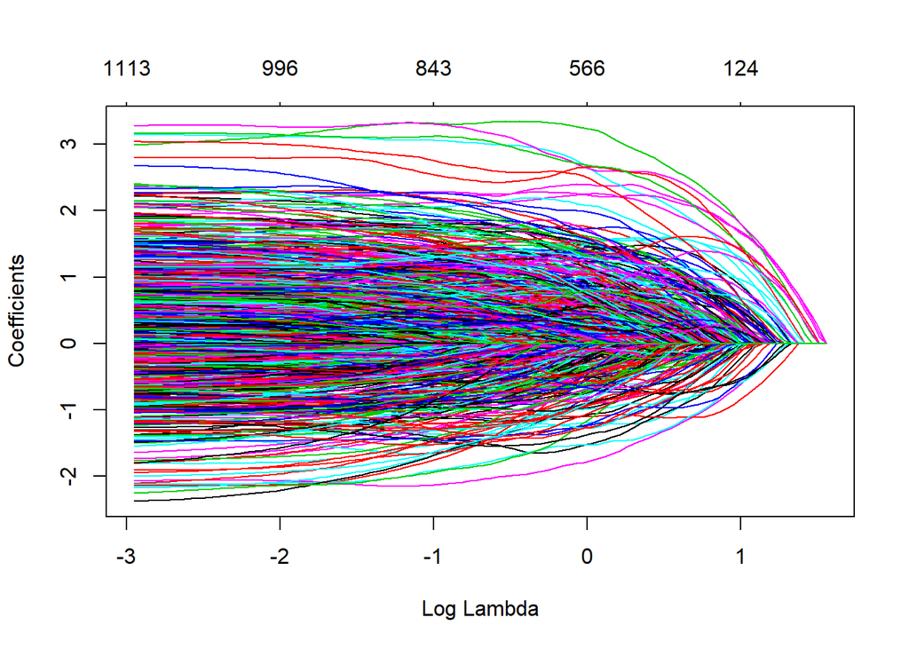

```r
plot(lasso3, xvar="lambda")
```

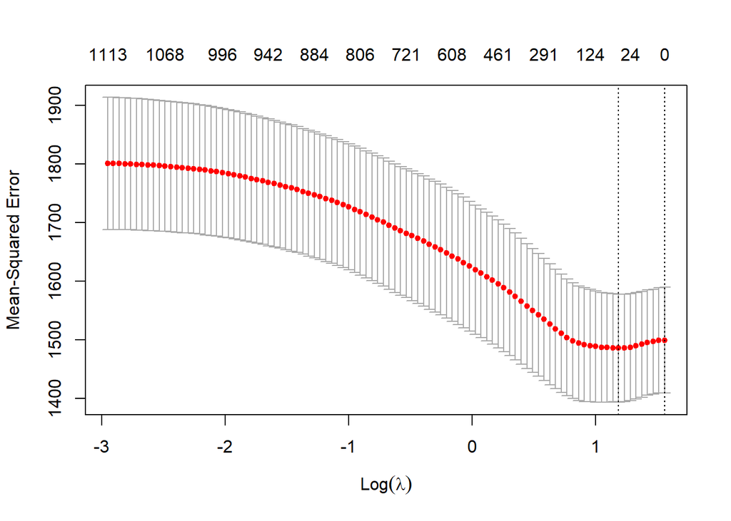

```r
plot(cvlasso3)
```

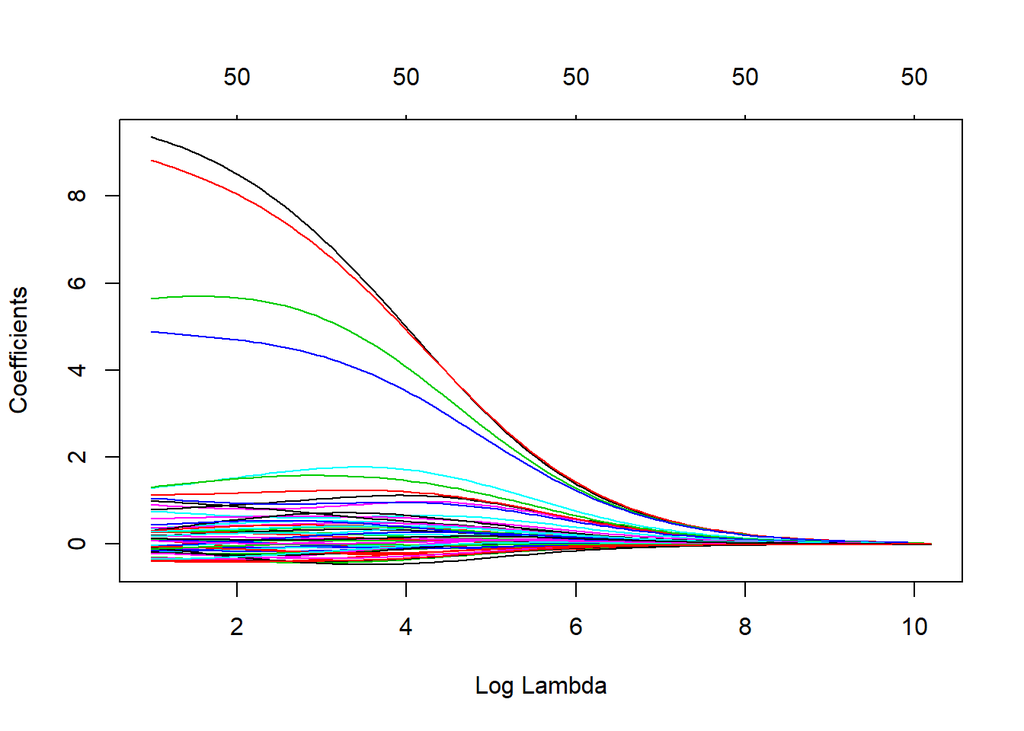

```r
plot(ridge3, xvar="lambda")
```

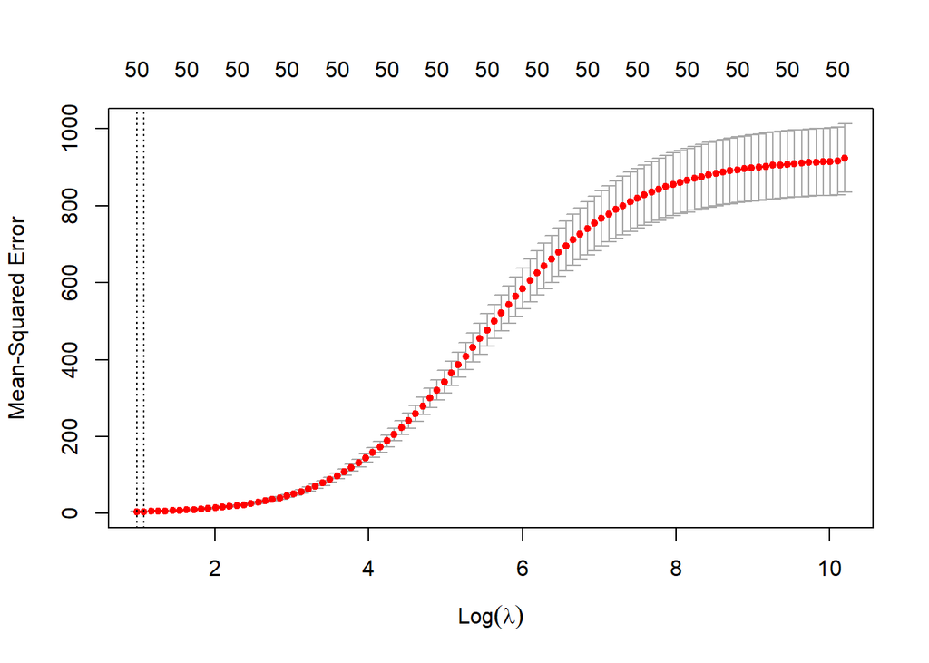

```r
plot(cvridge3)
```

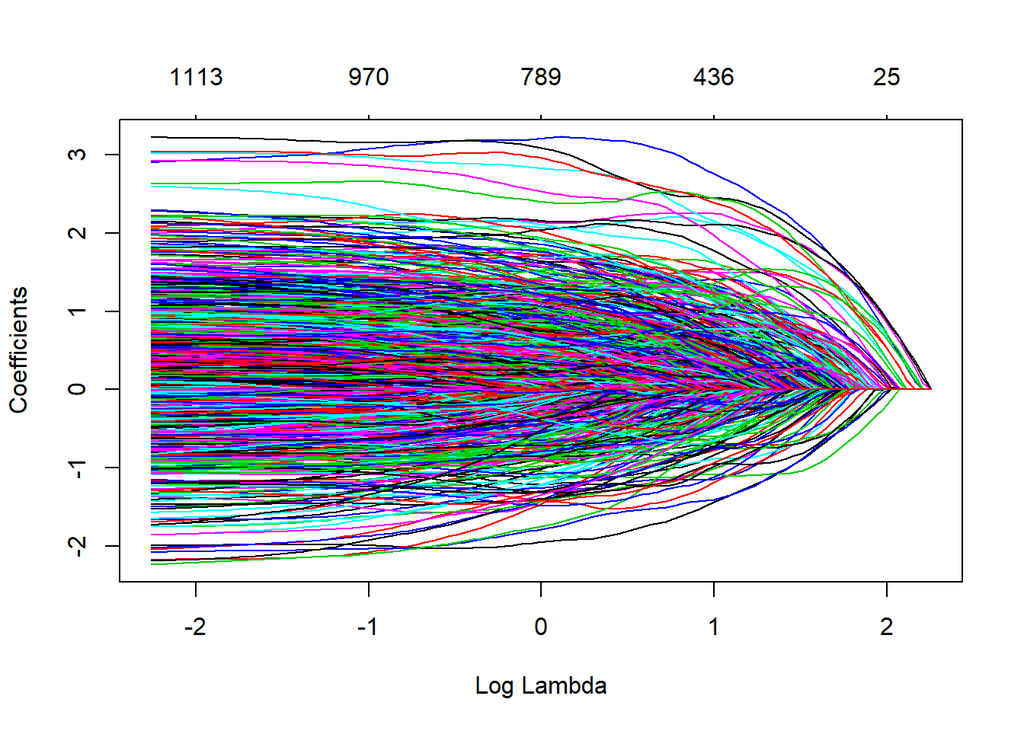

```r
plot(Elastic_net3, xvar="lambda")
```

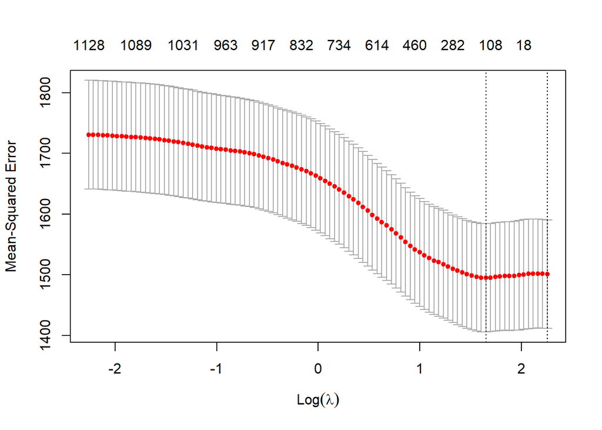

```r
plot(cvelastic_net3)
```

```r
cvlasso3$lambda.min
```

```
## [1] 3.281606
```

```r
cvridge3$lambda.min
```

```
## [1] 2.673805
```

```r
cvelastic_net3$lambda.min
```

```
## [1] 5.201233
```

L’estimateur ridge fournit la meilleure prédiction, car c’est le modèle qui retourne le plus petit minimum.